# Group 22 Analysis

Author

Group 22

# 1 Introduction

Email spam detection is an important application of statistical modelling because unwanted messages can reduce communication efficiency and increase security risks.  
For Group 22, the dataset contains several text-related variables that measure the frequency of specific characters or words in an email, together with a binary response variable indicating whether the email is classified as spam.

The aim of this analysis is to investigate which explanatory variables are associated with spam classification, and to prepare an appropriate basis for later generalised linear modelling.  
Before fitting any formal model, it is necessary to import the dataset, inspect its structure, and carry out basic cleaning checks to ensure that the analysis is reproducible and well documented.

# 2 Exploratory Analysis

## 2.1 Data import

This section begins by importing the original dataset for Group 22 from the project directory.

```r
# Read the original dataset from the project folder
spam_raw <- read_csv(here("dataset22.csv"))
```

## 2.2 Initial inspection

The dataset is then inspected to understand its structure, dimensions, variable names, and the first few observations.

```r
# Display the first few rows
head(spam_raw)
```

```
# A tibble: 6 × 7
  crl.tot dollar  bang money  n000  make yesno
    <dbl>  <dbl> <dbl> <dbl> <dbl> <dbl> <chr>
1     253  0.189 0.882  0     0.37  0    y
2     112  0.08  0      0     0     0    n
3      17  0     0.5    0     0     0    y
4     319  0     0.141  0     0     0    n
5     513  0.464 0.406  0     0.66  0.33 y
6    2049  0.157 0.502  0.08  0.42  0    y
```

```r
# Check the structure of the dataset
glimpse(spam_raw)
```

```
Rows: 920
Columns: 7
$ crl.tot <dbl> 253, 112, 17, 319, 513, 2049, 491, 354, 137, 67, 244, 166, 66,…
$ dollar  <dbl> 0.189, 0.080, 0.000, 0.000, 0.464, 0.157, 0.036, 0.000, 0.000,…
$ bang    <dbl> 0.882, 0.000, 0.500, 0.141, 0.406, 0.502, 0.000, 0.070, 0.000,…
$ money   <dbl> 0.00, 0.00, 0.00, 0.00, 0.00, 0.08, 0.00, 0.00, 0.00, 0.00, 0.…
$ n000    <dbl> 0.37, 0.00, 0.00, 0.00, 0.66, 0.42, 0.00, 0.00, 0.00, 0.00, 0.…
$ make    <dbl> 0.00, 0.00, 0.00, 0.00, 0.33, 0.00, 0.12, 0.00, 0.00, 0.00, 0.…
$ yesno   <chr> "y", "n", "y", "n", "y", "y", "n", "n", "n", "n", "n", "y", "y…
```

```r
# Check the dimensions of the dataset
dim(spam_raw)
```

```
[1] 920   7
```

```r
# Show variable names
names(spam_raw)
```

```
[1] "crl.tot" "dollar"  "bang"    "money"   "n000"    "make"    "yesno"
```

The initial inspection shows that the dataset contains 920 observations and 7 variables.  
The response variable `yesno` is initially stored as a character variable, while the remaining variables are numeric.

## 2.3 Data cleaning

The response variable is converted to the correct type, and basic checks are carried out for missing values and duplicated rows.

```r
# Create a cleaned copy for further processing
spam_clean <- spam_raw

# Convert the response variable to a factor
spam_clean <- spam_clean %>%
  mutate(yesno = factor(yesno))

# Check missing values in each column
colSums(is.na(spam_clean))
```

```
crl.tot  dollar    bang   money    n000    make   yesno
      0       0       0       0       0       0       0
```

```r
# Check duplicated rows
sum(duplicated(spam_clean))
```

```
[1] 210
```

The cleaning step confirms that there are no missing values in the dataset.  
The response variable `yesno` is converted to a factor so that it can be used appropriately in later classification modelling.  
In addition, 210 duplicated rows are detected. These are retained at this stage and noted for later discussion, rather than removed without justification.

## 2.4 Summary of cleaned data

Finally, a short summary of the cleaned dataset is produced to confirm that it is ready for later modelling.

```r
# Produce a quick overall summary of the cleaned dataset
skim(spam_clean)
```

Data summary

| Name | spam_clean |
| --- | --- |
| Number of rows | 920 |
| Number of columns | 7 |
| _______________________ |  |
| Column type frequency: |  |
| factor | 1 |
| numeric | 6 |
| ________________________ |  |
| Group variables | None |

**Variable type: factor**

| skim_variable | n_missing | complete_rate | ordered | n_unique | top_counts |
| --- | --- | --- | --- | --- | --- |
| yesno | 0 | 1 | FALSE | 2 | n: 557, y: 363 |

**Variable type: numeric**

| skim_variable | n_missing | complete_rate | mean | sd | p0 | p25 | p50 | p75 | p100 | hist |
| --- | --- | --- | --- | --- | --- | --- | --- | --- | --- | --- |
| crl.tot | 0 | 1 | 265.76 | 502.61 | 1 | 35.75 | 89.5 | 240.50 | 3498.00 | ▇▁▁▁▁ |
| dollar | 0 | 1 | 0.07 | 0.26 | 0 | 0.00 | 0.0 | 0.03 | 5.30 | ▇▁▁▁▁ |
| bang | 0 | 1 | 0.24 | 0.55 | 0 | 0.00 | 0.0 | 0.30 | 7.84 | ▇▁▁▁▁ |
| money | 0 | 1 | 0.07 | 0.30 | 0 | 0.00 | 0.0 | 0.00 | 6.66 | ▇▁▁▁▁ |
| n000 | 0 | 1 | 0.09 | 0.33 | 0 | 0.00 | 0.0 | 0.00 | 4.32 | ▇▁▁▁▁ |
| make | 0 | 1 | 0.12 | 0.36 | 0 | 0.00 | 0.0 | 0.00 | 4.34 | ▇▁▁▁▁ |

```r
# Frequency table for the response variable
tabyl(spam_clean$yesno)
```

```
 spam_clean$yesno   n   percent
                n 557 0.6054348
                y 363 0.3945652
```

The summary output confirms that the cleaned dataset is ready for subsequent analysis.  
The response variable is moderately imbalanced, with 557 non-spam emails (60.5%) and 363 spam emails (39.5%).

## 2.5 Dataset Overview

We start with the response variable `yesno`, which tells us whether an email is spam (`y`) or not spam (`n`).

Before moving to the plots, it is useful to clarify what the main variables represent:

- `crl.tot`: total length of uninterrupted capital letter sequences
- `dollar`: frequency of the dollar sign
- `bang`: frequency of exclamation marks
- `money`: frequency of the word `money`
- `n000`: frequency of the string `000`
- `make`: frequency of the word `make`

The frequency-based variables are measured relative to the length of each email, so they can be compared across messages of different sizes.

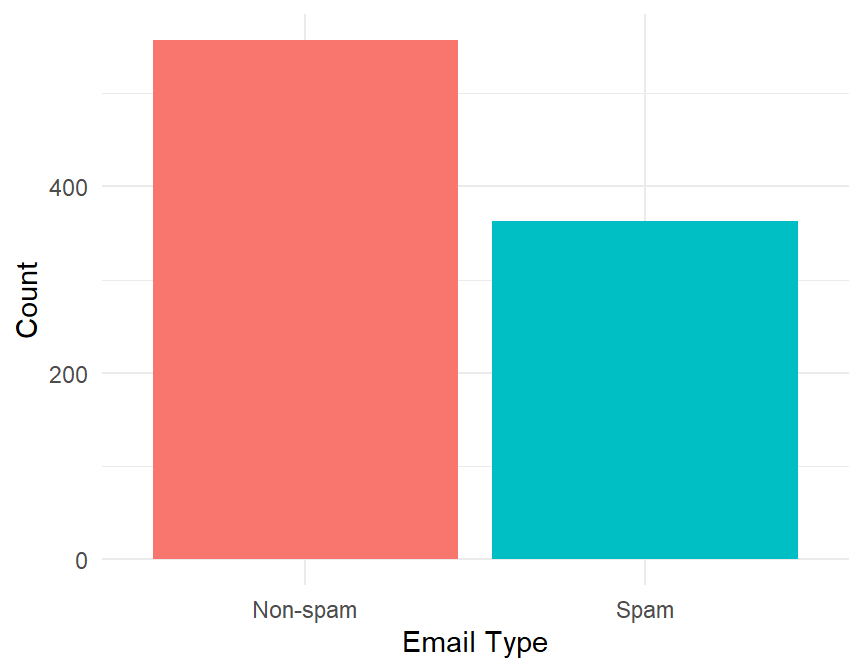

Figure 1: Spam and non-spam email counts.

As shown in Figure 1, there are 557 non-spam emails and 363 spam emails in the dataset. This corresponds to 60.5% non-spam and 39.5% spam, so there is some class imbalance, although it is not very large. The main aim of the EDA is therefore to identify which variables show the clearest separation between the two classes.

## 2.6 Grouped Summary of Predictors

Before interpreting the individual figures, it is useful to summarise each predictor by email type. This gives a clearer baseline for identifying separation, sparsity, and unusually large values.

Table 1: Grouped summary of predictors by email type.

| yesno | variable | mean | median | zero_pct | max |
| --- | --- | --- | --- | --- | --- |
| n | bang | 0.074 | 0.000 | 75.9% | 3.571 |
| n | crl.tot | 168.259 | 55.000 | 0.0% | 3467.000 |
| n | dollar | 0.010 | 0.000 | 89.6% | 0.427 |
| n | make | 0.101 | 0.000 | 84.2% | 4.340 |
| n | money | 0.005 | 0.000 | 98.7% | 0.800 |
| n | n000 | 0.006 | 0.000 | 97.1% | 0.960 |
| y | bang | 0.490 | 0.298 | 20.1% | 7.843 |
| y | crl.tot | 415.372 | 171.000 | 0.0% | 3498.000 |
| y | dollar | 0.158 | 0.051 | 43.8% | 5.300 |
| y | make | 0.145 | 0.000 | 67.8% | 2.350 |
| y | money | 0.177 | 0.000 | 66.4% | 6.660 |
| y | n000 | 0.219 | 0.000 | 71.1% | 4.320 |

Table 1 shows two clear features of the dataset. First, the punctuation- and word-based predictors contain many zeros, especially for non-spam emails, so simply whether a term appears or not already tells us something. Second, the predictors are strongly right-skewed, with some quite large maximum values, so medians and zero proportions are more useful here than means on their own.

## 2.7 Distribution of Capital Letter Sequences

With that overall summary in mind, it is helpful to start with `crl.tot`, which measures the total length of uninterrupted capital letter sequences in each email.

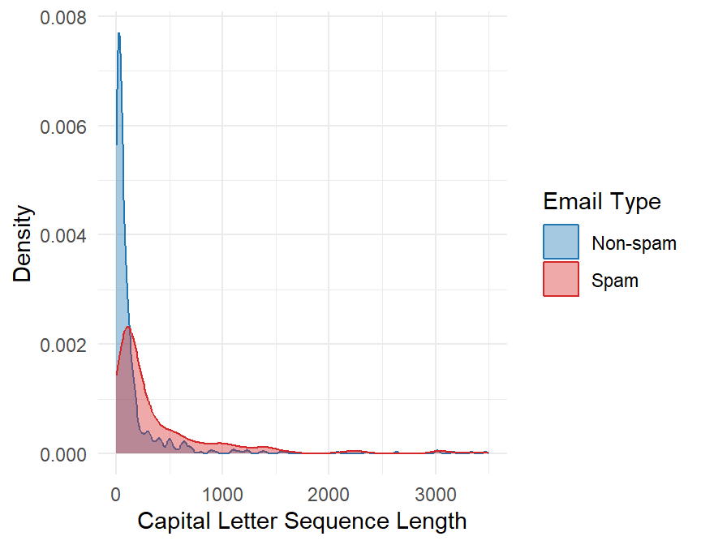

Figure 2: Capital letter sequence length by email type.

In Figure 2, both groups are concentrated at low values of `crl.tot`, but the spam distribution is shifted to the right and has a heavier tail. This matches Table 1, where the median of `crl.tot` is 171 for spam emails compared with 55 for non-spam emails, and the mean is also much larger (415.4 versus 168.3). There is still overlap between the two classes, but higher values of `crl.tot` are associated with a higher probability of spam classification, making it one of the clearest separating variables in the EDA.

Because `crl.tot` is strongly right-skewed, it is also helpful to look at the same variable on a log-transformed scale. This makes the separation in the main body of the distribution easier to see without being dominated by a small number of extreme values.

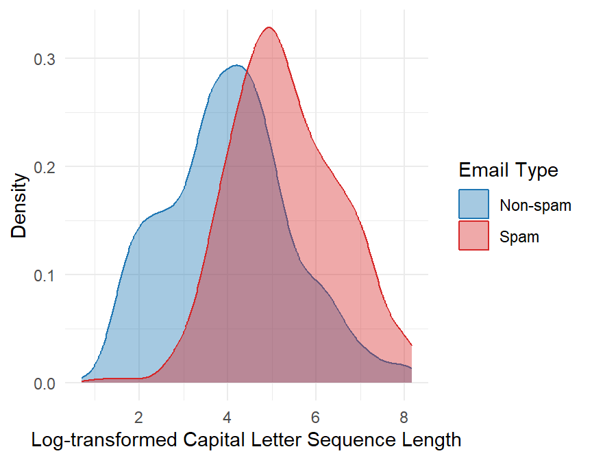

Figure 3: Log-transformed capital letter sequence length by email type.

In Figure 3, the extreme right tail is compressed and the class difference in the centre of the distribution becomes easier to compare. The spam emails still tend to have larger transformed values, which supports the earlier conclusion that `crl.tot` has a positive association with spam classification.

## 2.8 Dollar Sign Frequency

Another punctuation-based variable is `dollar`. It records how often the dollar symbol appears as a percentage of the total number of characters in the email.

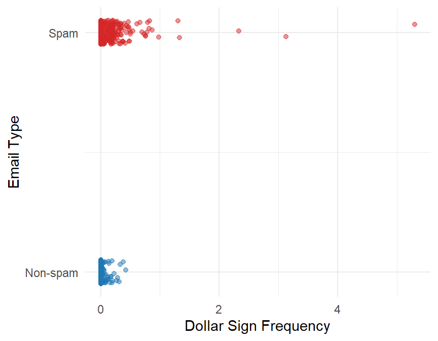

Figure 4: Dollar sign frequency by email type.

Looking at Figure 4, most observations are close to zero in both groups, but the difference between the classes is still clear. Dollar signs are absent in 89.6% of non-spam emails but only 43.8% of spam emails, and the spam median is 0.051 whereas the non-spam median is 0. This gap is large enough to make `dollar` one of the strongest single-variable signals in the EDA.

## 2.9 Exclamation Mark Frequency

The next punctuation-based variable is `bang`, which records the percentage of exclamation marks in each email.

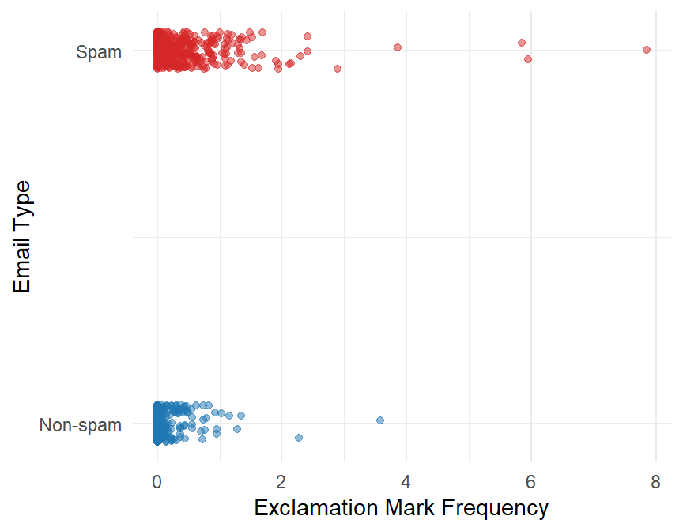

Figure 5: Exclamation mark frequency by email type.

The contrast in Figure 5 is stronger than for several of the other token-based variables. Exclamation marks are zero in 75.9% of non-spam emails but only 20.1% of spam emails, and the spam median (0.298) is clearly above the non-spam median of 0. Among the token-based predictors examined so far, `bang` shows one of the sharpest step changes between the two classes.

## 2.10 Frequency of the Word “Money”

The word-level indicators are much sparser. The variable `money` measures how frequently the word appears relative to the total number of characters in an email.

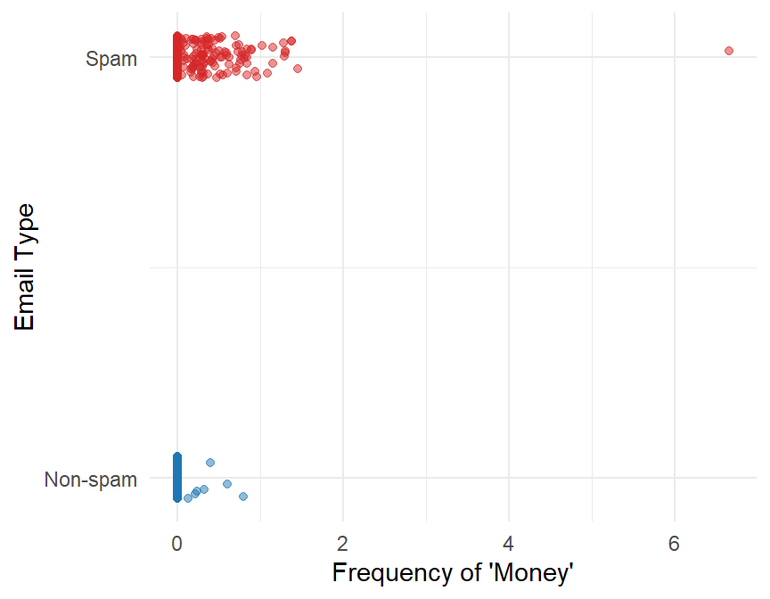

Figure 6: Frequency of the word “money” by email type.

The main feature in Figure 6 is that most values are zero: the median is 0 in both groups, and `money` is absent from 98.7% of non-spam emails and 66.4% of spam emails. Even so, the larger positive values occur much more often in spam emails. That makes `money` informative mainly when it is present, but clearly less separating than `dollar` or `bang`.

## 2.11 Frequency of “000”

Another sparse variable is `n000`, which measures how often the string `000` appears in each email.

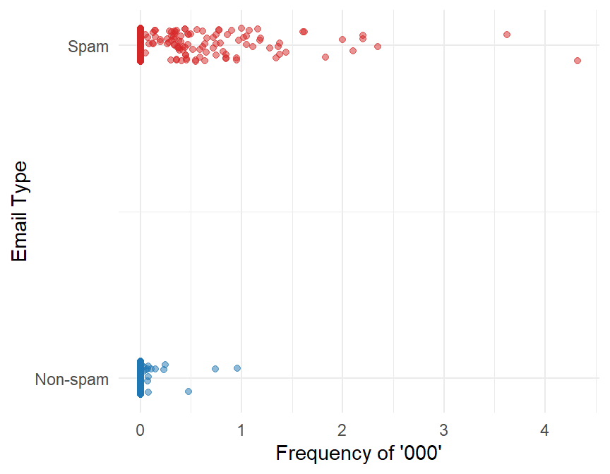

Figure 7: Frequency of “000” by email type.

In Figure 7, most observations are again close to zero, but the pattern is still useful. The string `000` is absent in 97.1% of non-spam emails and 71.1% of spam emails, so when it appears it is more common in spam. This puts `n000` in the same secondary group as `money` rather than the leading group formed by `dollar` and `bang`: the direction is informative, but the separation is limited by strong sparsity.

## 2.12 Frequency of the Word “Make”

The last variable we look at is `make`, which measures another word-based feature but appears to separate the two classes less clearly than the previous predictors.

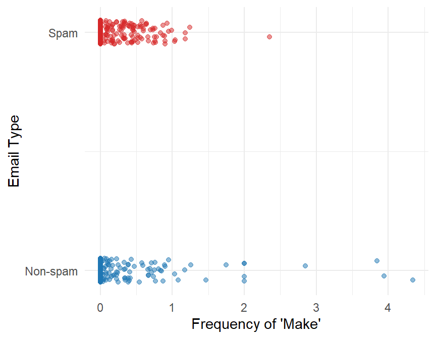

Figure 8: Frequency of the word “make” by email type.

Compared with the previous plots, Figure 8 shows weaker separation. The word `make` is still more common in spam emails, but the difference is smaller: it is absent in 84.2% of non-spam emails and 67.8% of spam emails, and the distributions overlap a lot. Against the clearer gaps for `bang` and `dollar`, the contrast here is modest, so `make` looks like the weakest predictor in this set.

## 2.13 Relationships Between Predictors

After looking at the predictors one by one, it is also useful to see whether some of them are telling us very similar things.

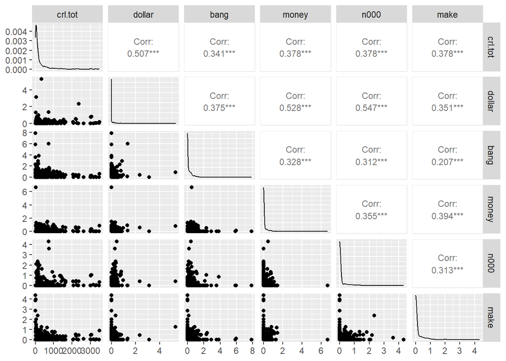

Figure 9: Pairwise relationships among the explanatory variables.

Table 2: Largest pairwise Spearman correlations among the predictors.

| var1 | var2 | correlation |
| --- | --- | --- |
| dollar | n000 | 0.547 |
| dollar | money | 0.528 |
| crl.tot | dollar | 0.507 |
| make | money | 0.394 |
| crl.tot | money | 0.378 |

As shown in Figure 9 and summarised in Table 2, most of the predictors are only weakly to moderately related. Table 2 reports Spearman rank correlations, and the upper panels of Figure 9 use the same measure, which is more appropriate here because several variables are strongly right-skewed and contain many zeros. The strongest rank correlation is between `dollar` and `n000`, but the overall pattern still suggests that no pair of predictors is strongly tied together. The lower panels of the scatterplot matrix remain useful because they show the raw pairwise patterns on the original scale, making it easier to check for obvious clustering or nonlinearity that a single correlation coefficient would miss. No strong alternative pattern stands out.

## 2.14 Sensitivity to Duplicate Rows

Because duplicated rows are fairly common in this dataset, it is also useful to check whether removing them changes the main EDA conclusions.

Of the 210 duplicated rows, 199 belong to non-spam emails and 11 belong to spam emails, so most of the duplication is in the non-spam class. After deduplication, the dataset contains 710 unique observations and the spam proportion rises to 49.6%, so the duplicates materially affect class balance. Even so, the strongest variables still tell a similar story: in the deduplicated data, the spam class still has a much larger median `crl.tot` (174 versus 89.5), a positive median `dollar` frequency (0.052 versus 0), and a positive median `bang` frequency (0.308 versus 0). This suggests that duplication changes the class balance more than it changes the leading signals in the EDA, although it should still be handled carefully in the later modelling stage.

## 2.15 Exploratory Analysis Summary

From the tables and plots above, `crl.tot`, `dollar`, and `bang` show the clearest separation between spam and non-spam emails. The variables `money` and `n000` sit a level below them: they are sparse, but their non-zero values still point in the same direction, while `make` shows the weakest relationship overall. Taken together, the stronger signals come mainly from emphatic formatting, punctuation, and promotional or financial language, which fits the kind of content often seen in spam emails. The predictors are not very strongly correlated with each other, so they seem to contribute different pieces of information rather than repeating the same signal. The data also show clear right-skew, many zero values, and a fairly large number of duplicated rows, mostly in the non-spam class. The duplicate check suggests that these repeated rows affect the class balance more than they affect the main separation seen in the strongest predictors. Overall, the EDA supports taking these variables forward into a logistic regression model, where their effects on the probability of spam classification can be assessed more formally.

# 3 Formal Analysis

# 4 Conclusions